# Homework 4: Modeling Pipeline

Maddi Hertz

8/15/2020

### Import Data

For this assignment I continued to work with the ANES. Here I import the cumulative data file to examine trends over time. Once again I ran into trouble importing the ANES cumulative file. R alerted me to import problems for over a million observations. Looking into it, I learned that R assigns variable type based on the first thousand observations. In the cumulative data file the first 1000 rows are all from the 1948 ANES which did not include many of the questions that became standard on later surveys. Consequently, R assigned data type `logical` to those variables with missing or `NA` values for the first thousand rows. From what I found on the online, the work around is to manually assign column types when importing, but admittedly this is quite ugly. My `read.delim` command includes the option `col_types` followed by a string of the letter ‘d’ 293 times to assign type `double` to 293 columns. I’d love to know if there is a better way to do this but could not find one in my research.

### Explore Variables of Interest

I am especially interested in modeling political efficacy, engagement, and trust and their effects on whether or not people vote. In general, my hypothesis is that people who distrust Washington and display low political efficacy are less likely to vote.

ANES asks a number of questions on trust, efficacy, and “system support”. The three I will focus on have been surveyed consistently over the years. I print tables for each to get a preliminary sense of the responses.

*How much if the time do you think you can trust the government in Washington to do what is right? (1958-2012)*

```
##          trustWash     n percent
##              Never   653    1.7%
##   Some of the time 22500   57.3%
##   Most of the time 14211   36.2%
##  Just about always  1908    4.9%
```

*I don’t think that public officials care much what people like me think. (1952-2016)*

```
##              careWhatIThink     n percent
##                       Agree 23330   50.5%
##                    Disagree 19439   42.1%
##  Neither agree nor disagree  3438    7.4%
```

*Sometimes politics and government seem so complicated that a person like me can’t really understand what’s going on. (1952-2012)*

```
##                 complicated     n percent
##                       Agree 25911   67.6%
##                    Disagree 10774   28.1%
##  Neither agree nor disagree  1621    4.2%
```

Notably, all three of these variables indicate that majorities of Americans distrustful or disillusioned with American democracy. As ANES categorizes these questions, “system support” from the American people is not very high. The United States has an extremely low voter turnout compared to other western democracies. My hypothesis is that these things are related—that low trust and political efficacy are associated with lower participation.

Ideally, I’d like to explore this question with a logistic regression that models whether someone will or will not vote. Obviously, there are many well tested likely voter models within the public opinion and survey research field. I do not think that modeling turnout primarily on efficacy and trust will be as accurate as those models, but I’m interested to find out whether it has explanatory value. In addition to the three variables I code above (`trustWash`, `careWhatIThink`, and `complicated`) I would like to include level of education and an index for racial resentment as independent variables.

Race has been an incredibly salient issue throughout modern political history and has dramatically changed the composition of the American electorate over the ANES survey years. I think it’s an important variable to include because the 2016 election demonstrated that racial resentment is a strong motivator for voters who may also have low trust in government. Given that Trump’s campaign echoed and built upon the tactics and dog whistles of previous presidential campaigns, I think it is likely that racial resentment has long worked counter to distrust, motivating people to vote.

I didn’t have enough of a background with logistic regression to confidently put together a model for this homework assignment, but I’m interested in potentially following through on this for the project. I would like to be pointed in the direction of some basic guidelines of what to lookout for when designing and evaluating simple logit models.

### Variable relationships

Instead, to demonstrate the relationship between my variables of interest and `didVote` my variable for turnout, I can use a Chi squared test. A Chi Squared test determines whether there is a statistically significant difference between the expected frequencies under the null the observed frequencies. Here the null hypothesis is that each group of survey respondents (ex. trust government “most of the time” "some of the time etc.) vote at the same rate and the alternative hypothesis is that groups of respondents vote at different rates.

```r
anes%>%
  tabyl(trustWash, didVote, show_na = FALSE)%>%
  adorn_percentages("row")%>%
  adorn_pct_formatting()
```

```
##          trustWash did not vote voted
##              Never        41.9% 58.1%
##   Some of the time        26.1% 73.9%
##   Most of the time        22.8% 77.2%
##  Just about always        31.0% 69.0%
```

```r
trustTable <- tabyl(anes, trustWash, didVote, show_na = FALSE)
chisq.test(trustTable)
```

```
##
##  Pearson's Chi-squared test
##
## data:  trustTable
## X-squared = 91.171, df = 3, p-value < 2.2e-16
```

```r
chisq.test(trustTable)$residuals
```

```
##          trustWash did not vote      voted
##              Never     5.738559 -3.3417943
##   Some of the time     1.646424 -0.9587788
##   Most of the time    -4.457735  2.5959188
##  Just about always     3.545343 -2.0645963
```

Immediately, it is clear that there is a statistically significant relationship between whether someone “trusts Washington to do what is right” and their propensity to vote. Based on the residuals, my hypothesis was correct that people who volunteer the response that they “never” trust Washington are significantly less likely to vote. Those who trust Washington “most of the time” are significantly more likely to vote. The result that I did not expect—though, upon reflection, is not that surprising—is that respondents who trust Washington implicitly, responding with “just about always” are **also** statistically less likely to vote. My initial interest in these variables was to better understand low information and low interest voters. I think that this is may be a window into a subset of those voters who are in effect so sure that everything will be taken care of that they are not motivated to participate in the political process. As I explore these data further, I will watch for more evidence of this high trust, low information, low interest, non-voter profile.

The Chi Squared tests of my other two variables of interest yield similar results in line with my hypotheses. People who believed public officials care about what they think are more likely to vote; those who do not believe they care are less likely to do so. Respondents who believed politics is too complicated for regular people to understand were statistically less likely to vote, while those who disagreed were more likely to vote.

```
##              careWhatIThink did not vote voted
##                       Agree        29.4% 70.6%
##                    Disagree        17.7% 82.3%
##  Neither agree nor disagree        26.2% 73.8%
```

```
##
##  Pearson's Chi-squared test
##
## data:  careTable
## X-squared = 506.08, df = 2, p-value < 2.2e-16
```

```
##              careWhatIThink did not vote     voted
##                       Agree    12.804549 -7.221251
##                    Disagree   -14.689474  8.284273
##  Neither agree nor disagree     2.054431 -1.158616
```

```
##                 complicated did not vote voted
##                       Agree        29.7% 70.3%
##                    Disagree        15.6% 84.4%
##  Neither agree nor disagree        29.3% 70.7%
```

```
##
##  Pearson's Chi-squared test
##
## data:  compTable
## X-squared = 549.62, df = 2, p-value < 2.2e-16
```

```
##                 complicated did not vote     voted
##                       Agree    10.685642 -6.260289
##                    Disagree   -16.993542  9.955835
##  Neither agree nor disagree     2.492377 -1.460184
```

### Another Visualization

I started this assignment by trying to create the visualization that I described in homework three tracking changes in trust over time. I ended up going in a different direction analyzing the relationship between trust and turnout, but I spent a lot of time working on this graph so I want to include it here as well.

In general, I expected to see trust in Washington decline over time but also thought it would shift in response to major political events. Initially I thought I was going to be able to trace trust from the 1960s through 2016, but midway through developing this visualization I was very disappointed to realize that I my data didn’t extend through 2016. I worked with the 2016 ANES trust question on my previous homework but didn’t realize that it wasn’t comparable to the trust question from previous surveys. In 2016 it was given as a 5 point question rather than the 3 point question that ANES had previous used.

The process of making this visualization was challenging. I found the `janitor` package and `tabyl` command that I used above after I was already done with this plot, but `tabyl` would have been quite helpful and now that I’ve found it I plan to clean up this code considerably. But the ugly original is worth including here to document my process (read: headaches) and the time I put into it.

`prop.table()` is not a very good tool because it erases all the metadata attached to original data frame; `tabyl` resolves that problem and is tidyverse friendly. The data frame that I ended up with after saving my prop.table was not in a functional or useful form whatsoever. It required a new round of tidying and multiple workarounds to solve really annoying problems. But thankfully, now that I’ve found `tabyl` I can get rid of all of this mess.

```r
# create and save prop.table of trust over time
trust_wash <- prop.table(xtabs(~ year + trustWash, anes), 1)
trust_wash <- as_tibble(trust_wash)

# preview new tibble
# notice that year is a character vector not numeric
trust_wash
```

```
## # A tibble: 96 x 3
##    year  trustWash        n
##    <chr> <chr>        <dbl>
##  1 1958  Never     0
##  2 1964  Never     0.000702
##  3 1966  Never     0.0260
##  4 1968  Never     0.00153
##  5 1970  Never     0.00272
##  6 1972  Never     0.00582
##  7 1974  Never     0.0131
##  8 1976  Never     0.0125
##  9 1978  Never     0.0415
## 10 1980  Never     0.0406
## # … with 86 more rows
```

```r
# pivot wider for tidy data
# I think pivot_wider is operating similar to spread() here
trust_wash <- trust_wash %>%
  pivot_wider(names_from = trustWash, values_from = n)
```

```r
# mutate to turn decimals into percentages
trust_wash <- trust_wash %>%
  mutate(never = `Never`*100,
         some = `Some of the time`*100,
         most = `Most of the time`*100,
         always = `Just about always`*100)

# create year vector to bind to trust_wash, then rename
# work around because I can't seem to coerce character vector into double vector
# is.numeric did not work
year <- c(1958, 1964, 1966, 1968, 1970, 1972, 1974, 1976, 1978, 1980, 1982, 1984,
          1986, 1988, 1990, 1992, 1994, 1996, 1998, 2000, 2002, 2004, 2008, 2012)

trust_wash <- bind_cols(trust_wash, year)

# ...10 is name of bound column - don't know option that assigns label within bind_cols()
trust_wash <- trust_wash%>%
  rename(yearchr = year) %>%
  rename(year = ...10) %>%
  mutate(presYear = if_else(year %% 4 == 0, 1, 0))
```

After I had the data in a tidy, functional form, I then had to *re-gather* it in order to plot multiple lines with ggplot. But despite my annoyance, the plot came out well.

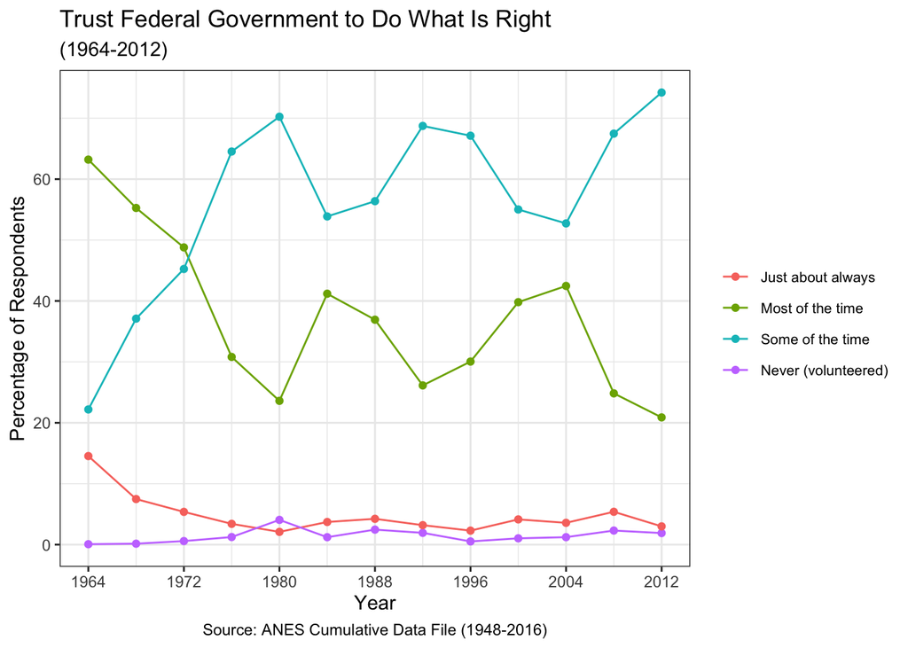

My hypothesis that trust would decline over over time was correct but only in part. Trust in Washington is at its lowest point in 2012 on this plot (and the non-comparable 2016 data shows trust has declined further), but my hypothesis was shaped by recency bias and personal experience, so I didn’t anticipate distrust also peaking 1980 and 1992. In retrospect, these peaks are unsurprising; they do correspond to important events in modern political history. In 1976 following the Watergate scandal trust falls significantly—on the graph the percentage of respondents who trust Washington to do the right thing “some of the time” jumps up and those responding “most of the time” falls by a corresponding amount. They continue to diverge in 1980 when the Iranian hostage crisis was a daily news event. Conversely, there is a predictable jump in trust 2004 when the rally around the flag effect of 9/11 and the invasion of Iraq was still being felt.